# The Tailor RNA-Seq Pipeline: a Tool for *De Novo* Disease Biomarker Identification

BIOL607 Final Project

Andrew Judell-Halfpenny

Fall Semester 2018

# Background

High-Throughput Sequencing is one of the most promising tools available to researchers united by the common-goals of personalized medicine. The first step towards providing targeted interventions for genetic diseases is identifying the genomic features common to a particular phenotype. Identifying a unique transcriptional signature through comparative RNA-Seq analysis enables earlier detection, informs future drug design, and ultimately saves lives. But identifying clinically informative features from the massive sequence libraries (~1-2 Tb) produced during one experiment exceed the capabilities of personal computers and necessitates the use of a high-performance computing cluster (HPCC). These circumstances create a skills-gap bottleneck that requires molecular biologists to develop extensive knowledge of computer programming and software engineering. This bottleneck is further exacerbated by the difficulty of identifying high-confidence population-level biomarkers from a small sample experiment with low statistical power. UMass Boston’s Genomics Core and Center for Personalized Cancer Therapy (CPCT) was established to resolve these issues and facilitate genomics research.

The Genomics core employs next-generation sequencing (NGS) technology for research and clinical applications in order to identify the genetic variants and the complex mechanisms involved in human disease. One of the ongoing projects at the CPCT focuses on prostate pathology. Fibrosis associated benign prostatic hyperplasia (BPH) is a chronic, progressive condition observed in 30-35% of men aged 60 or older (1). BPH is assotiated with a negative impact on patient quality of life due the concurrent development of a complex of lower urinary tract symptoms (LUTS) that include urgency, urinary frequency, weak urinary stream, and incomplete emptying of the bladder (2). Current surgical and medical interventions are not effective for all men and can produce siginificant adverse effects (3). This project represents an opportunity to explore the genetic mechanisms of fibrosis-asscoiated BPH and explore the efficacy of urinalysis diagnostics via the Tailor RNA-Seq pipeline for biomarker discovery. The Tailor Pipeline was designed to perform the comparative genomic analyses performed at UMass Boston’s CPCT and Genomics Core. Tailor is optimized for use with the unprocessed binary bcl data files produced by the Sequencing-by-Synthesis (SBS) protocol of an Illumina HiSeq 2500. Tailor’s analysis workflow enables biologists to extract RNA in a noninvasive manner from blood or urine and identify the causal genetic phenomena associated with the presentation of a diseased phenotype.

# Introduction to the Tailor Pipeline

The Tailor RNA-Seq analysis pipeline is an end-to-end tool-suite that produces a set of biomarkers from a comparative differential expression analysis between two or more conditions. Tailor extends and simplifies the Tophat-Cufflinks tool-suite for RNA-Seq library preparation in order to perform comparative gene expression analyses and visualize significant differences in the gene expression profiles between two or more conditions (5,6,7,8,9). The pipeline provides an automated workflow that facilitates resource requests over a HPCC through multi-step, in-parallel, computational “jobs” submitted to either LSF or SGE job-schedulers. Each step is initiated with a simple two-word command (“tailor fastqc,” “tailor trimgalore”) from a command-line interface. The output from each step is provided as input to the next step.

A user provided sample sheet maps the names of the input (bcl) files to the human readable sample names from each group or condition. Tailor uses gene model annotations and an indexed whole genome fasta file to quantify gene expression. Tailor includes *Bowtie* and other secondary tools for genome indexing and gene-model building for analyses with non-model organisms (6). Tailor’s workflow can be customized via modification of the provided settings configuration file. This feature enables the user to initiate the workflow from any step of the pipeline and utilizing most standard RNA-Seq file formats (fastq.gz, sam, bam, gtf, gff, cxb, and fg.gz). Several pre-configured settings files are included with Tailor to provide different levels of de-novo feature discovery. The default workflow does not perform any novel feature discovery while the genome-guided workflow uses gene-model annotations to guide isoform discovery.

# Experimental Design and Tailor’s Analysis Workflow:

In a recent comparative analysis between 9 males diagnosed with non-cancerous, fibrosis-associated, lower urinary tract syndrome (LUTS) and 9 canonically healthy males serving as a control group, Tailor analyzed ~1 Tb of RNA-Seq data over the course of 31 hours. The samples were provided by 9 males diagnosed with non-cancerous fibrosis-associated lower urinary tract syndrome and 9 males serving as an archetypal control group. RNA was extracted, ligated to sample-specific adapters, and multiplexed to reduce flow-cell lane bias. The pipeline began with file conversion and de-multiplexing via **bcl2fastq**, a tool designed by Illumina. **FastQC** quality control inspection of the sequence data was performed in order to check for over-represented sequences, anomalous features, and phred quality scores (10). The paired end reads were then parsed by **Trim-galore** in order to identify and trim the sample-specific adapter sequence that ligated the reads to the bottom of the flow-cell (11). After adapter trimming, the sequence libraries were mapped to the hg38 reference genome by **Tophat**, a splice aware mapper (4,5). After read-mapping, the transcripts were assembled by Cufflinks into de-Bruijn graphs (6). **Cufflinks** determined each gene’s isoform structure from bipartite matching the isoforms into a minimum-spanning-trees (mst) that accounts for the distribution of all of the reads arising from a particular gene (6). After the transcripts are assembled, a gene transfer format file was produced for each sample and compared to the reference annotation by **Cuffmerge** (6,7). The new gene models and the mapped bam files from the Tophat step are input to **Cuffquant** for gene expression quantification (6,7). The gene models and the gene expression files were input to **Cuffdiff** for comparative differential expression analysis (6,8,9). Cuffdiff modeled the gene expression using an overdispersed Poisson-model. The variance is calculuated as a function of the mean gene expression. Cuffdiff calculates dispersion from the variance present in a group beyond what is expected from a simple Poisson model. Tailor calls Cuffdiff to perform means tests of the expression values for each gene across both conditions. Cuffdiff outputs gene expression values (FPKM),log-fold-change expression values, FDR corrected p-values (q-values), p-values, and their associated test-statistic from the means tests of the distribution of expression values for each gene accross both conditions. Biomarker candidates were identified from q-values below $\alpha=0.05$. Cuffdiff output served as input for CummeRbund, a Bioconductor package that produces visually digestible summations of the salient features from RNA-Seq data (12).

# Results/Summary of the Investigation:

Tailor used Tophat to align the libraries of paired-end sequence data to UCSC’s hg38 Homo sapiens reference genome yielding a per-sample average overall mapping rate of 94.0% with a minimum overall mapping rate of 82.3%. Average concordant pair-mapping rate to the hg38 genome was 82.2% with a minimum per-sample concordant pair-mapping rate of 66.8%. Tailor assembled transcripts for 32245 genes, 92397 isoforms, 54249 coding sequences. Tailor detected sufficient expression levels to identify significant differential expression for 25171 coding sequences, 15118 genes, and 32316 isoforms. Of the features with adequate expression levels, 115 coding sequences, 370 genes, and 251 isoforms were identified as significantly differentially expressed.

```r
cuff<- readCufflinks(dir='/home/drew/umb_triley/urine1/cuffdiff_results_hg38_default/LUTS-over-CTRL/',genome="/home/drew/umb_triley/Reference-Genomes-and-Gene-Sets/Reference-Genomes/Human/UCSC_hg38/genome.fa",gtfFile='/home/drew/umb_triley/Reference-Genomes-and-Gene-Sets/Reference-Genomes/Human/UCSC_hg38/genes.gtf', rebuild=F)
cuff
```

```
## CuffSet instance with:
##   2 samples
##   26372 genes
##   56891 isoforms
##   36510 TSS
##   38679 CDS
##   26225 promoters
##   36510 splicing
##   19164 relCDS
```

```r
replicates.info<-cummeRbund::replicates(cuff)
replicates.info
```

```
##                                                           file sample_name
## 1   cuffquant_results_hg38_default/Sample_3_out/abundances.cxb        CTRL
## 2   cuffquant_results_hg38_default/Sample_5_out/abundances.cxb        CTRL
## 3   cuffquant_results_hg38_default/Sample_7_out/abundances.cxb        CTRL
## 4   cuffquant_results_hg38_default/Sample_9_out/abundances.cxb        CTRL
## 5  cuffquant_results_hg38_default/Sample_11_out/abundances.cxb        CTRL
## 6  cuffquant_results_hg38_default/Sample_13_out/abundances.cxb        CTRL
## 7  cuffquant_results_hg38_default/Sample_15_out/abundances.cxb        CTRL
## 8  cuffquant_results_hg38_default/Sample_17_out/abundances.cxb        CTRL
## 9  cuffquant_results_hg38_default/Sample_19_out/abundances.cxb        CTRL
## 10  cuffquant_results_hg38_default/Sample_4_out/abundances.cxb        LUTS
## 11  cuffquant_results_hg38_default/Sample_6_out/abundances.cxb        LUTS
## 12  cuffquant_results_hg38_default/Sample_8_out/abundances.cxb        LUTS
## 13 cuffquant_results_hg38_default/Sample_10_out/abundances.cxb        LUTS
## 14 cuffquant_results_hg38_default/Sample_12_out/abundances.cxb        LUTS
```

[output cut: 23 more lines]

```r
groups<-replicates.info$sample_name
samples<-replicates.info$rep_name
conditions<-as.factor(groups)
conditions
```

```
##  [1] CTRL CTRL CTRL CTRL CTRL CTRL CTRL CTRL CTRL LUTS LUTS LUTS LUTS LUTS
## [15] LUTS LUTS LUTS LUTS
## Levels: CTRL LUTS
```

```r
samples
```

```
##  [1] "CTRL_0" "CTRL_1" "CTRL_2" "CTRL_3" "CTRL_4" "CTRL_5" "CTRL_6"
##  [8] "CTRL_7" "CTRL_8" "LUTS_0" "LUTS_1" "LUTS_2" "LUTS_3" "LUTS_4"
## [15] "LUTS_5" "LUTS_6" "LUTS_7" "LUTS_8"
```

```r
groups
```

```
##  [1] "CTRL" "CTRL" "CTRL" "CTRL" "CTRL" "CTRL" "CTRL" "CTRL" "CTRL" "LUTS"
## [11] "LUTS" "LUTS" "LUTS" "LUTS" "LUTS" "LUTS" "LUTS" "LUTS"
```

```r
under=groups[1]
over=groups[((length(groups)/2)+1)]
over;under
```

```
## [1] "LUTS"
```

```
## [1] "CTRL"
```

```r
# design matrix
design <- model.matrix(~0 +groups, data=replicates.info)
colnames(design) <- levels(conditions)
row.names(design) <- samples
design
```

```
##        CTRL LUTS
## CTRL_0    1    0
## CTRL_1    1    0
## CTRL_2    1    0
## CTRL_3    1    0
## CTRL_4    1    0
## CTRL_5    1    0
## CTRL_6    1    0
## CTRL_7    1    0
## CTRL_8    1    0
## LUTS_0    0    1
## LUTS_1    0    1
## LUTS_2    0    1
## LUTS_3    0    1
## LUTS_4    0    1
## LUTS_5    0    1
## LUTS_6    0    1
## LUTS_7    0    1
## LUTS_8    0    1
## attr(,"assign")
## [1] 1 1
## attr(,"contrasts")
## attr(,"contrasts")$groups
## [1] "contr.treatment"
```

```r
# contrast matrix
contr.matrix <- makeContrasts(LUTS - CTRL,
                               levels = design)

contr.matrix
```

```
##       Contrasts
## Levels LUTS - CTRL
##   CTRL          -1
##   LUTS           1
```

```r
# gene expr data
gene_exp.df<-diffData(cummeRbund::genes(cuff))
#g.cnt.matrix<-repCountMatrix(cummeRbund::isoforms(cuff))
g.cnt.matrix<-repCountMatrix(cummeRbund::genes(cuff))
# factors for conditions
under.group<-grep(pattern=under, colnames(g.cnt.matrix))
over.group<-grep(pattern=over, colnames(g.cnt.matrix))

# Library Sizes
colSums( g.cnt.matrix )
```

```
##   CTRL_0   CTRL_1   CTRL_2   CTRL_3   CTRL_4   CTRL_5   CTRL_6   CTRL_7
## 11882040 12511447 18492880 11337240 11593500 12244492 15549069 11447407
##   CTRL_8   LUTS_0   LUTS_1   LUTS_2   LUTS_3   LUTS_4   LUTS_5   LUTS_6
## 12015349 11384100 12668196 14971358 13717578 16030915 11100257 16226846
##   LUTS_7   LUTS_8
## 10987524 18909776
```

```r
# Library Sizes in millions of reads
colSums( g.cnt.matrix ) / 1e06
```

```
##   CTRL_0   CTRL_1   CTRL_2   CTRL_3   CTRL_4   CTRL_5   CTRL_6   CTRL_7
## 11.88204 12.51145 18.49288 11.33724 11.59350 12.24449 15.54907 11.44741
##   CTRL_8   LUTS_0   LUTS_1   LUTS_2   LUTS_3   LUTS_4   LUTS_5   LUTS_6
## 12.01535 11.38410 12.66820 14.97136 13.71758 16.03092 11.10026 16.22685
##   LUTS_7   LUTS_8
## 10.98752 18.90978
```

# Extended Analysis Section:

To refine the biomarker set produced by Tailor, repeated differential expression analyses were performed in the R statistical programming environment (13). **EdgeR** and **Limma**, two commonly used Bioconductor packages for differential expression analysis, were employed to reanalyze the data and mitigate the influence of biases resulting from choise of software in the biomarker gene-set (14,15,16,17,18). Raw read counts extracted from Tailor’s SQLite database backend via CummeRbund (12) were used as input for the additional analyses.

## Filtering and Normalizing Gene Expression Values

```r
## filter the data enough to perform Shapiro-Wilk normality test
g.CPM.ma <- cpm(g.cnt.matrix, prior.count=1)
str(g.CPM.ma)
```

```
##  num [1:26372, 1:18] 0 0 0.0629 128.6665 0 ...
##  - attr(*, "dimnames")=List of 2
##   ..$ : chr [1:26372] "A1BG" "A1BG-AS1" "A1CF" "A2M" ...
##   ..$ : chr [1:18] "CTRL_0" "CTRL_1" "CTRL_2" "CTRL_3" ...
```

```r
g.LCPM.ma <- cpm(g.cnt.matrix, log=TRUE, prior.count=1)
str(g.LCPM.ma)
```

```
##  num [1:26372, 1:18] -3.76 -3.76 -2.87 7.01 -3.76 ...
##  - attr(*, "dimnames")=List of 2
##   ..$ : chr [1:26372] "A1BG" "A1BG-AS1" "A1CF" "A2M" ...
##   ..$ : chr [1:18] "CTRL_0" "CTRL_1" "CTRL_2" "CTRL_3" ...
```

```r
## filter genes with at less than 1 cpm in at least 9 samples
keep.exprs <- rowSums(g.LCPM.ma > 1) >= length(groups)/2
table(keep.exprs)
```

```
## keep.exprs
## FALSE  TRUE
## 15981 10391
```

```r
# Subset the rows of countdata to keep the more highly expressed genes
g.f.cnt.ma <- as.data.frame(g.LCPM.ma[keep.exprs,])
str(g.f.cnt.ma)
```

```
## 'data.frame':    10391 obs. of  18 variables:
##  $ CTRL_0: num  7.01 8.38 4.44 -3.76 2.2 ...
##  $ CTRL_1: num  7.72 8.73 2.64 4.21 2 ...
##  $ CTRL_2: num  -3.76 6.14 6.89 -3.76 -3.76 ...
##  $ CTRL_3: num  7.33 6.35 3.72 2.23 4.82 ...
##  $ CTRL_4: num  9.73 7.78 3.23 5.03 3.02 ...
##  $ CTRL_5: num  6.42 -2.76 -3.76 4.15 -2.76 ...
##  $ CTRL_6: num  6.57 8.79 6.57 -3.76 7.48 ...
##  $ CTRL_7: num  8.07 9.63 4.8 3.76 3.78 ...
##  $ CTRL_8: num  9.124 10.289 3.798 0.893 -2.344 ...
##  $ LUTS_0: num  8.38 6.48 -2.99 5.3 5.22 ...
##  $ LUTS_1: num  6.38 8.05 3.59 -3.76 4.39 ...
##  $ LUTS_2: num  6.09 9.42 -2.56 6.87 -1.91 ...
##  $ LUTS_3: num  5.683 9.804 0.613 -3.755 -3.755 ...
##  $ LUTS_4: num  6.31 10.13 -3.76 5.16 -3.76 ...
##  $ LUTS_5: num  9.45 5.23 2.76 4.34 4.24 ...
##  $ LUTS_6: num  -1.79 10.83 6.67 1.52 2.52 ...
##  $ LUTS_7: num  7.77 8.58 4.91 4.7 1.91 ...
##  $ LUTS_8: num  6.594 -1.458 -0.843 -3.755 1.618 ...
```

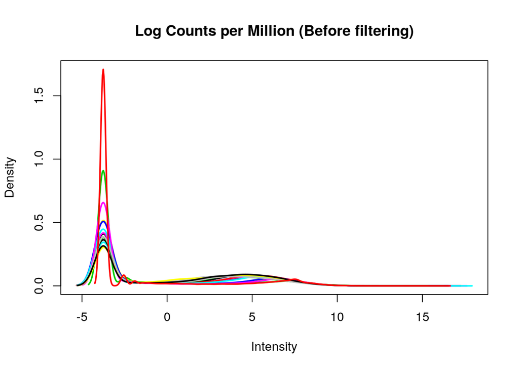

```r
# Visualize distribution of gene expression levels
plotDensities(g.LCPM.ma, legend = FALSE, main = "Log Counts per Million (Before filtering)")
```

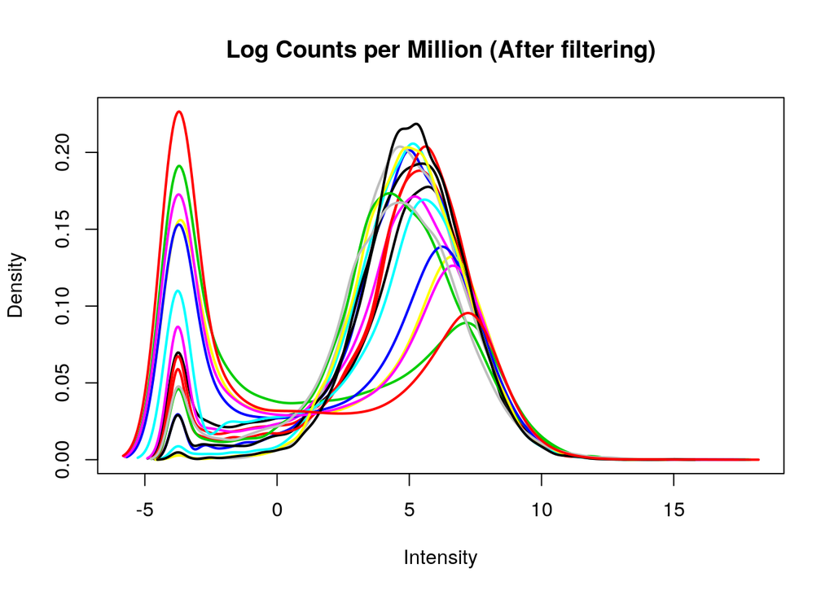

```r
# Visualize distribution of gene expression levels
plotDensities(g.f.cnt.ma, legend = FALSE, main = "Log Counts per Million (After filtering)")
```

```r
# visualize coefficient of variation

# Test normality
norm.1st.group<-apply(g.f.cnt.ma[1:round(nrow(g.f.cnt.ma)/3),], 1, function(x) shapiro.test(x)$p.value)
sum(norm.1st.group < 0.05)
```

```
## [1] 2775
```

```r
norm.2nd.group<-apply(g.f.cnt.ma[c(round(nrow(g.f.cnt.ma)/3):c(2*round(nrow(g.f.cnt.ma)/3))),], 1, function(x) shapiro.test(x)$p.value)
sum(norm.2nd.group < 0.05)
```

```
## [1] 2697
```

```r
norm.3rd.group<-apply(g.f.cnt.ma[c(((2*round(nrow(g.f.cnt.ma)/3))+1):nrow(g.f.cnt.ma)),], 1, function(x) shapiro.test(x)$p.value)
sum(norm.3rd.group < 0.05)
```

```
## [1] 2760
```

```r
# visualize
keep.cpm <- rowSums(cpm(g.cnt.matrix) > 1) >= (length(groups)/2)
table(keep.cpm)
```

```
## keep.cpm
## FALSE  TRUE
## 15338 11034
```

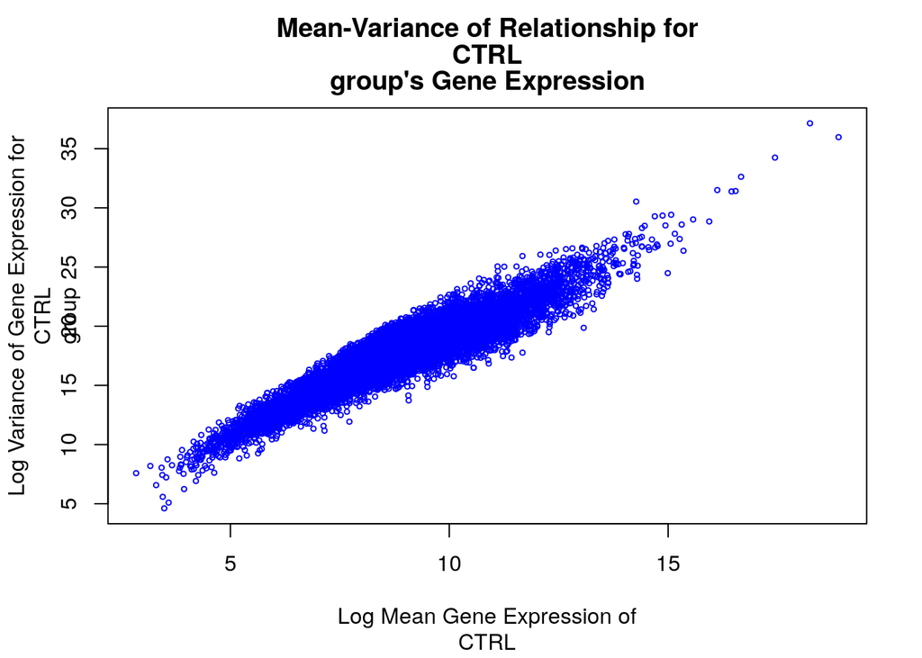

```r
g.f.cnt.ma <- g.cnt.matrix[keep.cpm,]
g.u.cnt.mu = rowMeans(as.matrix(g.f.cnt.ma[,under.group]))
g.o.cnt.mu = rowMeans(as.matrix(g.f.cnt.ma[,over.group]))
g.u.cnt.vars = rowVars(as.matrix(g.f.cnt.ma[,under.group]))
g.o.cnt.vars = rowVars(as.matrix(g.f.cnt.ma[,over.group]))

plot(log2(g.u.cnt.vars) ~ log2(g.u.cnt.mu),
     main=c("Mean-Variance of Relationship for", under,"group's Gene Expression"),
     xlab=c("Log Mean Gene Expression of", under),
     ylab=c("Log Variance of Gene Expression for", under, "group"),
     cex = .5, col = "blue")
```

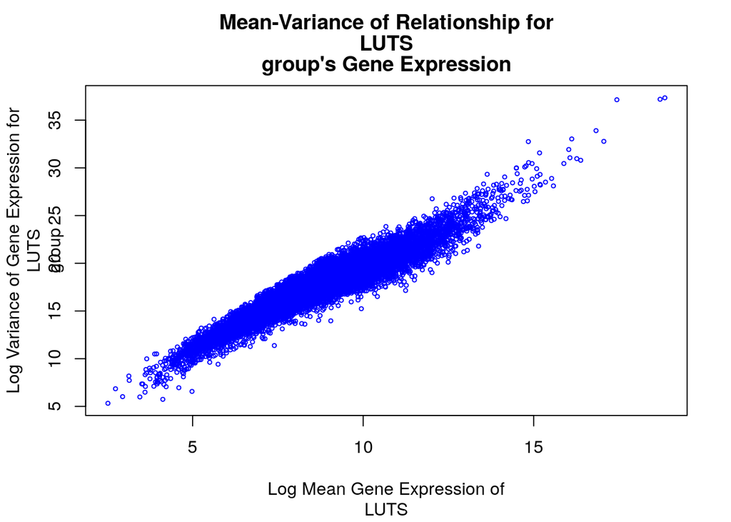

```r
plot(log2(g.o.cnt.vars) ~ log2(g.o.cnt.mu),
     main=c("Mean-Variance of Relationship for", over,"group's Gene Expression"),
     xlab=c("Log Mean Gene Expression of", over),
     ylab=c("Log Variance of Gene Expression for", over, "group"),
     cex = .5, col = "blue")
```

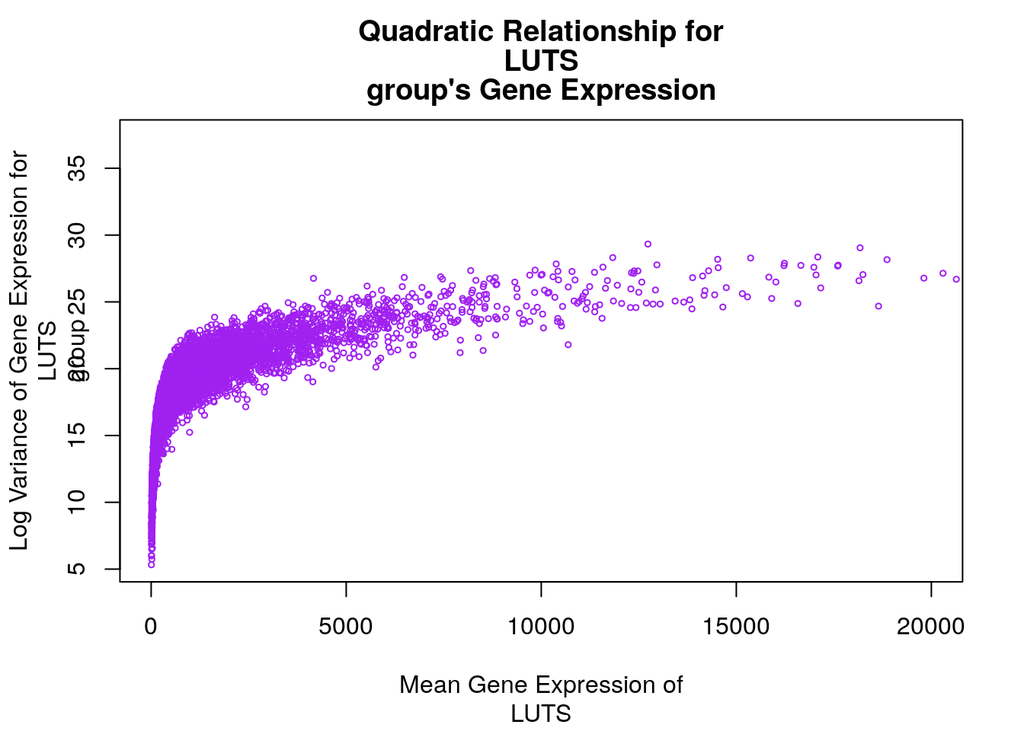

```r
plot(log2(g.o.cnt.vars) ~ g.o.cnt.mu,
     main=c("Quadratic Relationship for", over,"group's Gene Expression"),
     xlab=c("Mean Gene Expression of", over), xlim=c(0, 20000),
     ylab=c("Log Variance of Gene Expression for", over, "group"),
     cex = .5, col = "purple")
```

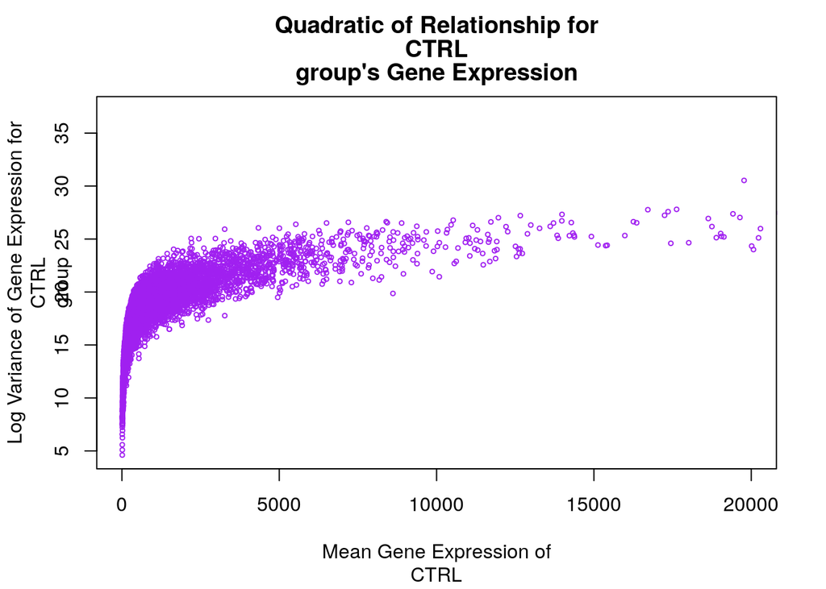

```r
plot(log2(g.u.cnt.vars) ~ g.u.cnt.mu,
     main=c("Quadratic of Relationship for", under,"group's Gene Expression"),
     xlab=c("Mean Gene Expression of", under),xlim=c(0, 20000),
     ylab=c("Log Variance of Gene Expression for", under, "group"),
     cex = .5, col = "purple")
```

```r
g.f.cnt.sds <- rowSds(as.matrix(g.f.cnt.ma))
#effect.size<-sqrt((g.u.cnt.mu - g.o.cnt.mu)^2)/g.f.cnt.sds
g.cnt.fstats = rowFtests(as.matrix(g.f.cnt.ma), as.factor(groups))
g.cnt.s.fstats<-subset(g.cnt.fstats, p.value < 0.05)
num.pval<-nrow(g.cnt.fstats)
num.sig.pvals<-sum(g.cnt.fstats$p.value < 0.05)
true.sig<-c(num.pval *0.05)
sig.calls<-c((num.pval *0.05)-num.sig.pvals)
typeIIerrs<-true.sig-sig.calls
typeIIerr.rate<-c(true.sig-sig.calls)/nrow(g.cnt.fstats)
power=1-typeIIerr.rate
power
```

```
## [1] 0.9811492
```

```r
ftest.sigs<-row.names(g.cnt.s.fstats)
```

## Limma Linear Models

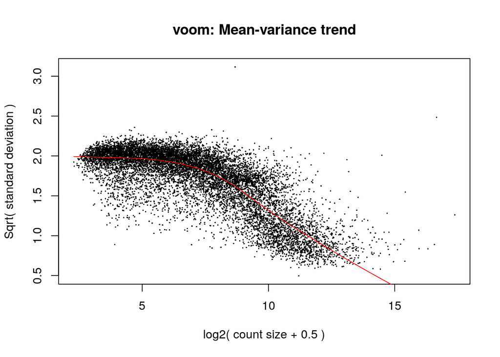

```r
dgel<- DGEList(counts=g.f.cnt.ma, group=factor(groups))
log2.cpm <- voom(dgel,design,plot=TRUE)
```

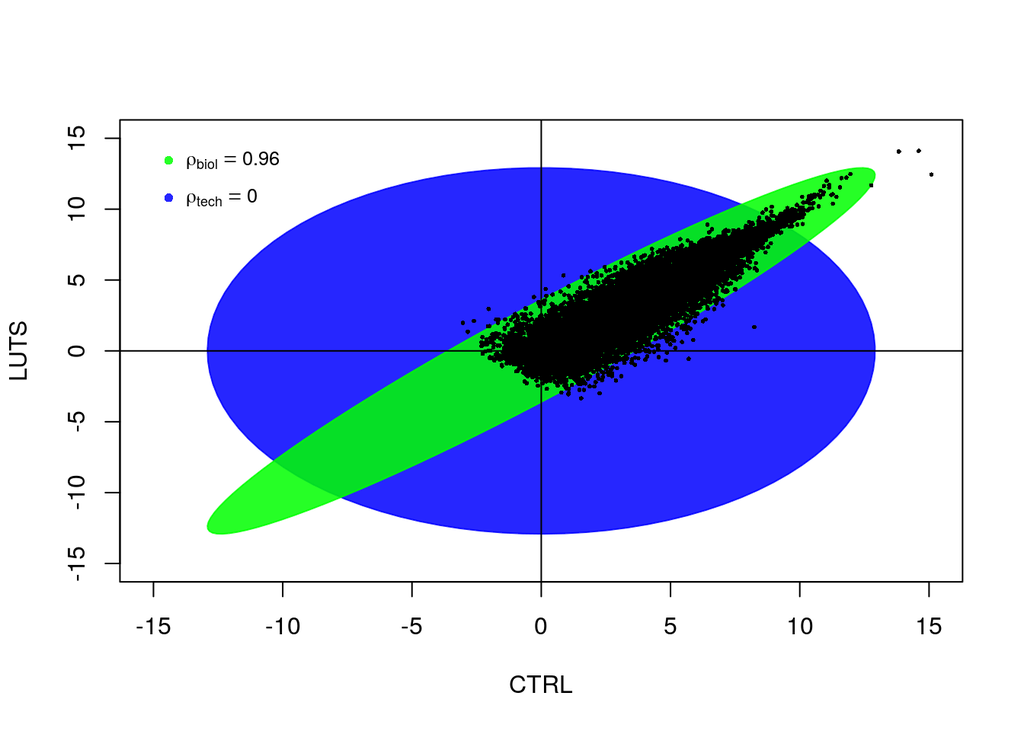

```
## $technical.correlation
## [1] 0
##
## $covariance.matrix
##          [,1]     [,2]
## [1,] 19.59492 17.88496
## [2,] 17.88496 17.70680
##
## $biological.correlation
## [1] 0.960166
##
## $deviance
## [1] 25649.24
##
## $p.value
## [1] 0
##
## $n
## [1] 11034
```

```r
fit.lm <- lmFit(log2.cpm,design,weights=log2.cpm$weights)
genas(fit.lm, coef=c(1,2), plot=TRUE, subset="all",alpha=0.85)
```

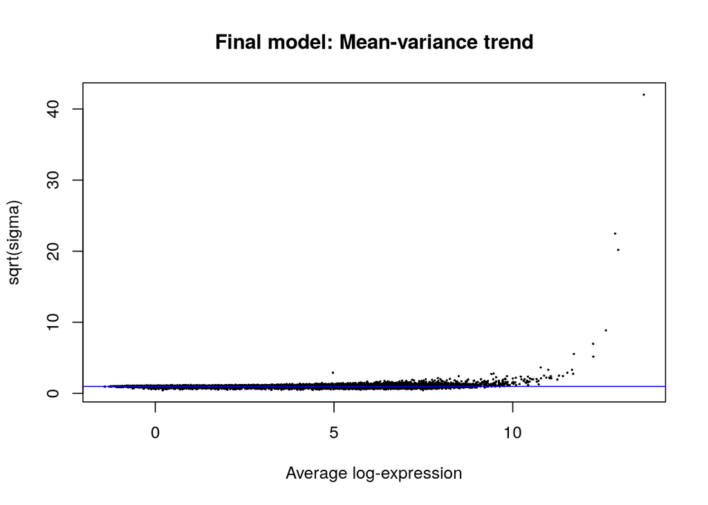

```r
fit2 <- contrasts.fit(fit.lm, contr.matrix)
#  Estimate biological correlation between the logFC profiles
fit.bayes <- eBayes(fit2)
tfit <- treat(fit.bayes,lfc=1)
plotSA(fit.bayes, main="Final model: Mean-variance trend")
```

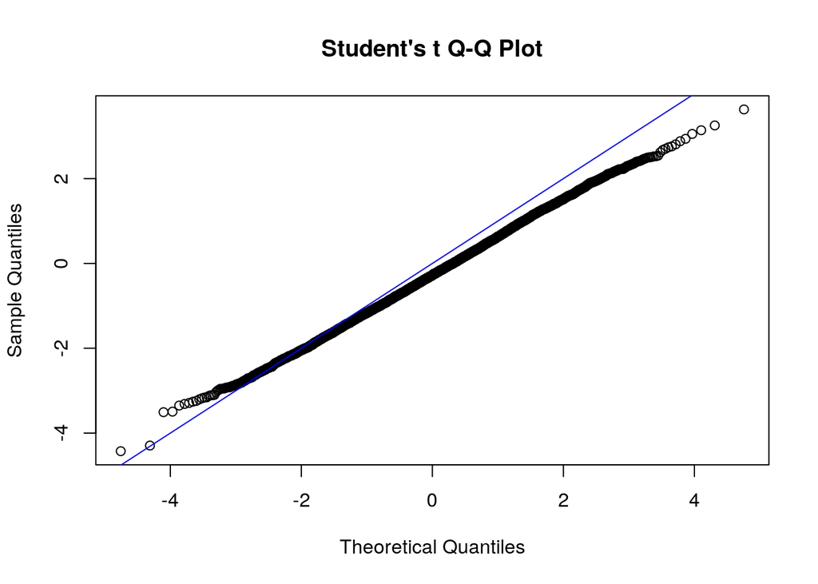

```r
# Q-Q plot of moderated t-statistics
qqt(fit.bayes$t[,1], df=fit.bayes$df.residual+fit.bayes$df.prior)
   abline(0,1, col="blue")
```

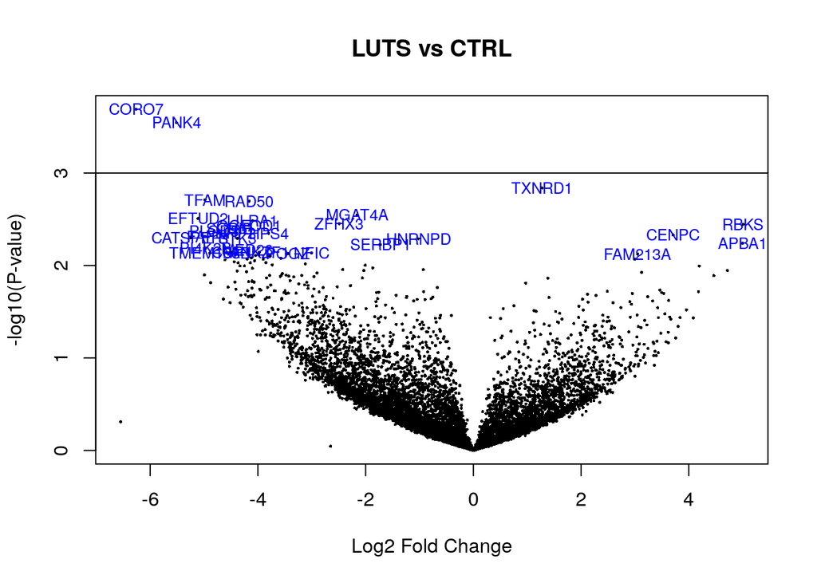

```
## integer(0)
```

```r
# Fold-change thresholding
# Treat relative to a 10% fold-change
sig.tfit<-subset(tfit$p.value, tfit$p.value < 0.05)
volcanoplot(fit.bayes,coef=1,highlight=30,names=row.names(fit.bayes$p.value),main="LUTS vs CTRL")+
   abline(h=3)
```

```r
fdr.rate<-sum(tfit$F.p.value <0.05)-sum(tfit$p.value <0.05)
power<-1-fdr.rate/length(tfit$p.value)
power
```

```
## [1] 0.9761646
```

```r
limma.sigs<-row.names(sig.tfit)
```

## EdgeR Analysis

```r
# design matrix
design <- model.matrix(~groups, data=replicates.info)
colnames(design) <- levels(conditions)
row.names(design) <- samples
design
```

```
##        CTRL LUTS
## CTRL_0    1    0
## CTRL_1    1    0
## CTRL_2    1    0
## CTRL_3    1    0
## CTRL_4    1    0
## CTRL_5    1    0
## CTRL_6    1    0
## CTRL_7    1    0
## CTRL_8    1    0
## LUTS_0    1    1
## LUTS_1    1    1
## LUTS_2    1    1
## LUTS_3    1    1
## LUTS_4    1    1
## LUTS_5    1    1
## LUTS_6    1    1
## LUTS_7    1    1
## LUTS_8    1    1
## attr(,"assign")
## [1] 0 1
## attr(,"contrasts")
## attr(,"contrasts")$groups
## [1] "contr.treatment"
```

```r
# contrast matrix
contr.matrix <- makeContrasts(LUTS - CTRL,CTRL - LUTS,
                               levels = design)
contr.matrix
```

```
##       Contrasts
## Levels LUTS - CTRL CTRL - LUTS
##   CTRL          -1           1
##   LUTS           1          -1
```

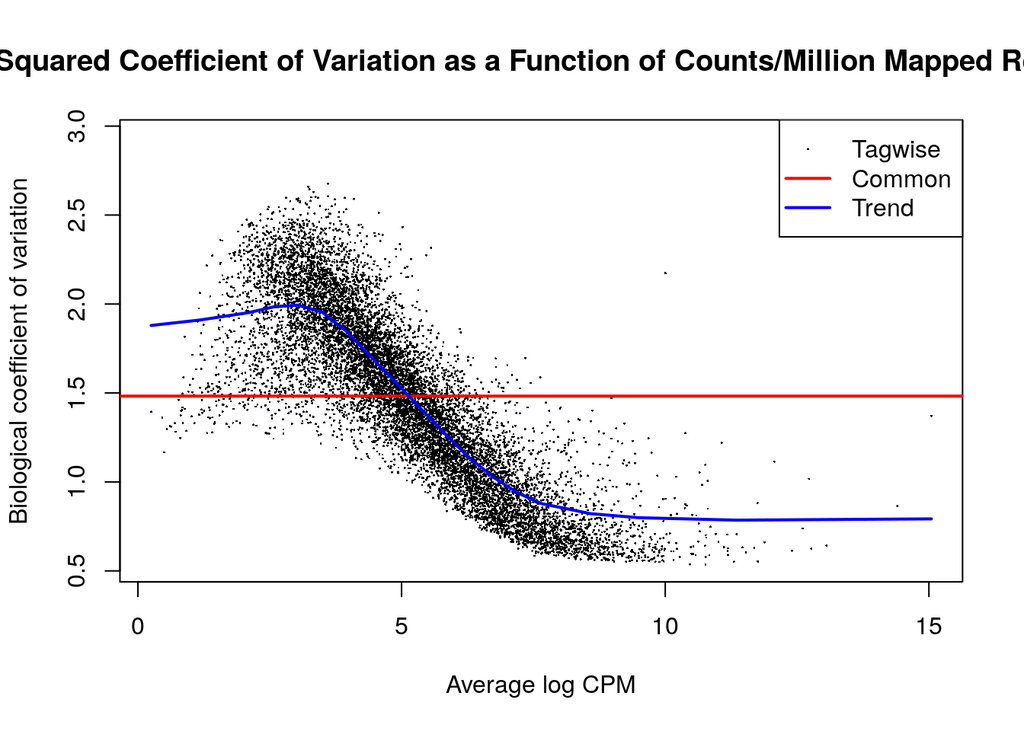

```r
de.obj <- DGEList(counts=g.f.cnt.ma,group=groups)
disp <- estimateDisp(de.obj,design)
plotBCV(disp, main="Squared Coefficient of Variation as a Function of Counts/Million Mapped Reads")
```

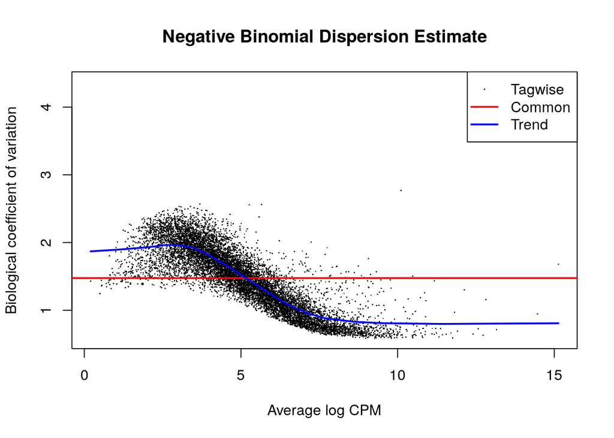

```r
norm.factor <- calcNormFactors(de.obj)
f.disp <- estimateDisp(norm.factor,design, robust=TRUE)
plotBCV(f.disp, main="Negative Binomial Dispersion Estimate")
```

```r
f.disp$common.dispersion
```

```
## [1] 2.174653
```

```r
# coefficient of variation
sqrt(f.disp$common.dispersion)
```

```
## [1] 1.474671
```

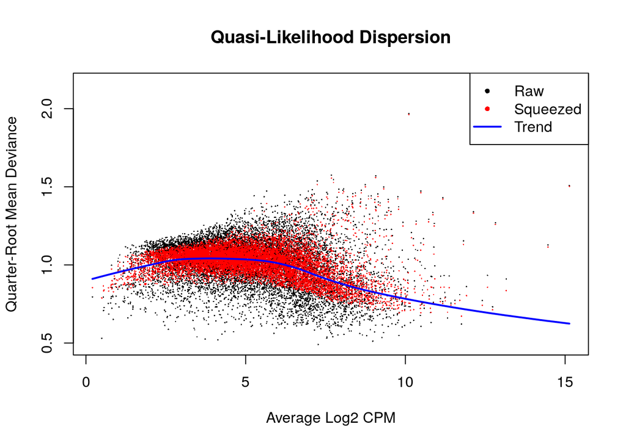

```r
#To perform quasi-likelihood F-tests:
fit <- glmQLFit(f.disp,design, robust=TRUE)
plotQLDisp(fit,main="Quasi-Likelihood Dispersion")
```

```r
contr.matrix <- makeContrasts(CTRL - LUTS,
                               levels = design)
contr.matrix
```

```
##       Contrasts
## Levels CTRL - LUTS
##   CTRL           1
##   LUTS          -1
```

```r
qlf <- glmQLFTest(fit,coef=2,contrast=contr.matrix)
tr <- glmTreat(fit, coef=2, lfc=1)
glm.treat.DE <-tr$table[tr$table$PValue < 0.05,]
edger.sigs<-row.names(glm.treat.DE)
```

# Results/Summary of Initial Tailor Analysis:

```r
genes_exp.df<-diffData(cummeRbund::genes(cuff))
sig.genes.df<-subset(genes_exp.df, genes_exp.df$significant=="yes")
l.sig.genes.df<-subset(genes_exp.df, genes_exp.df$gene_id %in% limma.sigs)
l.sig.genes.df$gene_id
```

```
##   [1] "AAMDC"        "AGPAT5"       "ANKZF1"       "APBA1"
##   [5] "ATAT1"        "AXL"          "B3GNT7"       "BANF1"
##   [9] "CATSPER1"     "CBR1"         "CDAN1"        "CENPC"
##  [13] "CES2"         "CLOCK"        "CLPTM1L"      "COA3"
##  [17] "CORO7"        "CRTC1"        "DDX24"        "EFNB1"
##  [21] "EFTUD2"       "EXOSC10"      "FAF1"         "FAM213A"
##  [25] "FANCF"        "FDXACB1"      "FRAS1"        "GBA2"
##  [29] "GLB1"         "GLE1"         "GNG5"         "GPR180"
##  [33] "GSS"          "HDAC10"       "HMBS"         "HPS4"
##  [37] "ICAM3"        "IL10RA"       "JMJD7"        "KIAA1033"
##  [41] "LDLRAD3"      "LIG3"         "LILRA1"       "LINC00969"
##  [45] "LOC100129617" "LTF"          "MAP1S"        "MAP3K1"
##  [49] "MB21D2"       "MED26"        "METTL7A"      "MGAT4A"
##  [53] "MINA"         "NCBP2"        "NDUFA8"       "NEU1"
##  [57] "NFIB"         "NFIC"         "NHP2"         "NIFK"
##  [61] "NOL10"        "OASL"         "OGFOD1"       "PANK4"
##  [65] "PCNP"         "PEX5"         "PFDN2"        "PHF11"
##  [69] "PI4K2B"       "PLOD3"        "PLP2"         "PNKD"
##  [73] "POGZ"         "PON2"         "PPP1R13B"     "QTRTD1"
##  [77] "RAB43"        "RAD50"        "RBKS"         "RPL27"
##  [81] "SCRIB"        "SDCCAG8"      "SEC63"        "SHMT2"
##  [85] "SLC1A4"       "SLC2A4RG"     "SLC35F5"      "SLC4A2"
##  [89] "SLC7A6OS"     "SLFN12"       "SORBS3"       "SSBP4"
##  [93] "STK3"         "SYMPK"        "TELO2"        "TFAM"
##  [97] "TMCO3"        "TMEM138"      "TMEM198B"     "TOP3B"
## [101] "TP73-AS1"     "TPD52"        "TRAF3IP2-AS1" "TSR3"
## [105] "TULP4"        "TXNDC11"      "UBE2J2"       "UCHL5"
## [109] "UPP1"         "YTHDF1"       "ZDHHC4"       "ZFHX3"
## [113] "ZNF142"       "ZNF587B"
```

```r
e.sig.genes.df<-subset(genes_exp.df, genes_exp.df$gene_id %in% edger.sigs)
e.sig.genes.df$gene_id
```

```
##  [1] "AAMDC"        "ANKZF1"       "APBA1"        "BZW2"
##  [5] "C14orf105"    "C19orf70"     "C1orf112"     "C5AR2"
##  [9] "CAMKK1"       "CATSPER1"     "CCDC113"      "CCDC146"
## [13] "CD209"        "CDC23"        "CENPC"        "DBT"
## [17] "DMBT1"        "DNAJC24"      "DTD2"         "ERVV-1"
## [21] "FAM122C"      "FAM213A"      "FANCF"        "FLVCR1"
## [25] "FRAT1"        "FZD3"         "GFRA1"        "HES4"
## [29] "HMBS"         "KCNK5"        "KLK2"         "KLK4"
## [33] "LINC00969"    "LOC101929450" "LTF"          "MIR17HG"
## [37] "MIR6723"      "MSMO1"        "MUT"          "NCDN"
## [41] "NMNAT2"       "OASL"         "OPLAH"        "PALM2"
## [45] "PANK4"        "PDE4C"        "PDGFA"        "RABGEF1"
## [49] "RAD50"        "RBKS"         "SLC2A4RG"     "SLC7A6OS"
## [53] "STARD5"       "STK3"         "SYT15"        "SYT2"
## [57] "TIGD6"        "TLR3"         "TMEM136"      "TMEM198B"
## [61] "TMEM55A"      "TP73-AS1"     "UBE2J2"       "XKR9"
## [65] "YBEY"         "ZDHHC4"       "ZNF568"       "ZNF674"
```

```r
f.sig.genes.df<-subset(genes_exp.df, genes_exp.df$gene_id %in% ftest.sigs)
f.sig.genes.df$gene_id
```

```
##   [1] "ACHE"         "ADAMTSL4"     "AGK"          "AKAP5"
##   [5] "ANKLE2"       "ANXA2"        "APEX2"        "ARHGAP11A"
##   [9] "ARMCX6"       "ARSD"         "ATXN1L"       "BAG6"
##  [13] "BRAF"         "BRF1"         "C15orf57"     "C1GALT1"
##  [17] "C1orf106"     "C2orf42"      "CALCOCO1"     "CD209"
##  [21] "CDAN1"        "CENPC"        "CEP104"       "CEP89"
##  [25] "CHIC2"        "CHMP7"        "CLMN"         "CLPTM1L"
##  [29] "CMTR1"        "CORO7"        "CPNE8"        "CPT2"
##  [33] "CSF2RA"       "CXorf38"      "CYB561D2"     "CYP1B1"
##  [37] "CYP2R1"       "DBNDD2"       "DLGAP2"       "DLL1"
##  [41] "DNAJC2"       "EGLN1"        "ELMOD2"       "EMX2"
##  [45] "EPHB2"        "ERBB2IP"      "ERCC1"        "FAM105A"
##  [49] "FAM107B"      "FAM208B"      "FAM213A"      "FAN1"
##  [53] "FANCF"        "FDXACB1"      "FGD5-AS1"     "FKBP5"
##  [57] "FOXP4"        "FRAT1"        "FRS2"         "GAS2L3"
```

[output cut: 37 more lines]

```r
fl.sigs<-f.sig.genes.df$gene_id %in% l.sig.genes.df$gene_id
fl.sigs<-f.sig.genes.df[fl.sigs,]
fl.sigs$gene_id
```

```
##  [1] "CDAN1"        "CENPC"        "CLPTM1L"      "CORO7"
##  [5] "FAM213A"      "FANCF"        "FDXACB1"      "GBA2"
##  [9] "GLB1"         "HPS4"         "LDLRAD3"      "LILRA1"
## [13] "LOC100129617" "MGAT4A"       "NEU1"         "NFIC"
## [17] "NHP2"         "NIFK"         "PANK4"        "PEX5"
## [21] "PLP2"         "POGZ"         "RBKS"         "SCRIB"
## [25] "SEC63"        "SLC2A4RG"     "SLC35F5"      "SLC4A2"
## [29] "SLFN12"       "SORBS3"       "TFAM"         "TMEM138"
## [33] "TP73-AS1"     "TRAF3IP2-AS1" "TXNDC11"      "UCHL5"
## [37] "YTHDF1"       "ZFHX3"
```

```r
fe.sigs<-f.sig.genes.df$gene_id %in% e.sig.genes.df$gene_id
fe.sigs<-f.sig.genes.df[fe.sigs,]
fe.sigs$gene_id
```

```
##  [1] "CD209"        "CENPC"        "FAM213A"      "FANCF"
##  [5] "FRAT1"        "LOC101929450" "MIR6723"      "PANK4"
##  [9] "RABGEF1"      "RBKS"         "SLC2A4RG"     "TP73-AS1"
```

```r
gene_exp.fl.df<-gene_exp.df$gene_id %in% fl.sigs$gene_id
fl.genes<-which(gene_exp.fl.df==TRUE)
fl_gene_exp.df<-gene_exp.df[fl.genes,]

gene_exp.fe.df<-gene_exp.df$gene_id %in% fe.sigs$gene_id
fe.genes<-which(gene_exp.fe.df==TRUE)
fe_gene_exp.df<-gene_exp.df[fe.genes,]
fle.sigs<-fl_gene_exp.df$gene_id %in% fe_gene_exp.df$gene_id
biomarker.set<-fl_gene_exp.df[fle.sigs,]
length(biomarker.set)
```

```
## [1] 11
```